# DS Final Project Proposal

Jennifer Osei, Haoyang Wang, Angelica Vina Albarrancin, William Anderson, Riya Bhilegaonkar 2022-11-12

## Team registration and proposal

First, you will define your teams and propose a project. This proposal should be a half-page to a page in length and include:

## The Group Members (names and UNIs)

William Anderson - waa2119 Riya Bhilegaonkar - rsb2204 Jennifer Osei - jao2195 Haoyang Wang - hw2850 Angelica Vina Albarrancin - av2718

## The Tentative Project Title:

NYC Bills of Mortality: Investigating the leading causes of death in New York City

## The Motivation for this Project:

In this project, we hope to analyze NYC’s leading causes of death from 2007-2019, focusing on individual-level factors (e.g., personal income) and community-level factors (e.g., access to green spaces) to better understand how these factors contribute to the leading causes of the death in the city. We decided to focus on NYC as it’s the largest city in the US and one of the world’s most diverse cities. We chose the period of 2007-2019 to focus on the modern causes of death in the city while avoiding confounding factors due to the COVID-19 outbreak.

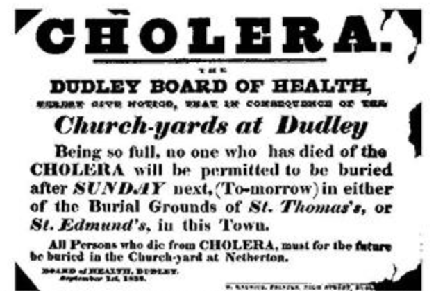

## The Intended Final Products:

Webpage that includes visualizations and test results for the impact of various predictors such as age, income, race, education status, air quality, green spaces, etc., on leading causes of death in NYC. Each page of the website will contain an analysis of a predictor done by each individual in the group. The final product will be a data story that contains reference to historical progression of leading causes of death as informed through epidemiology.

## The Anticipated Data Sources:

Helpful NYC Health Data Resources:

- https://opendata.cityofnewyork.us/
- https://www.health.ny.gov/statistics/
- https://www.health.ny.gov/statistics/sparcs/access/

Income data:

- https://www.point2homes.com/US/Neighborhood/NY/New-York-City-Demographics.html
- https://www.incomebyzipcode.com/newyork
- https://www.nyc.gov/site/hpd/services-and-information/area-median-income.page

Age Data: * https://health.data.ny.gov/Health/Vital-Statistics-Deaths-by-Region-and-Age-Group-by/c3ns-hz2v

- https://health.data.ny.gov/Health/Vital-Statistics-Opioid-Related-Deaths-by-Age-Grou/qabx-2sqw
- https://health.data.ny.gov/Health/Vital-Statistics-Suicide-Deaths-by-Age-Group-Race-/j6fz-a4ta

## The Planned Analyses / Visualizations / Coding Challenges:

William Anderson is focusing on analyzing income as a predictor for different diseases that are the leading cause of death in NYC by analyzing the following:

- Plot the correlation between income level and life expectancy
- Conduct statistical analysis to understand if income plays a role in the survival probability of cancer, heart disease, and other diseases
- Visualize a map of neighborhoods in NYC with certain income levels and the number of healthcare facilities within a certain radius
- Stratify the leading causes of death by income level and observe trends

Riya Bhilegaonkar is focusing on analyzing age as a predictor for different diseases that are the leading cause of death in NYC by analyzing the following:

Haoyang Wang is focusing on investigating the top leading causes of death in NYC and the high morbidity of Cerebrovascular Disease in NYC by analyzing the following:

- Visualize the top leading causes of death in NYC by morbidity with bar plot.
- Visualize the top leading causes of death in NYC by neighborhood.
- Analyze the major factors contributing to one of the top leading causes of death in NYC, Cerebrovascular Disease.
- Conducting statistical analyses investigating the correlation between these factors and NYC. In other ways, does NYC has a higher morbidity of Cerebrovascular Disease and why.

Angelica Vina-Albarracin will focus on Alzheimer’s disease and other causes of dementia in NYC:

- Visualize changes over time in Alzheimer’s disease diagnoses and the number of deaths attributed to Alzheimer.
- Conduct statistical analysis to understand the relationship between individual-level factors such as income, years of education, family history, etc., and the risk of death from Alzheimer’s diseases.
- Analyze and visualize the distribution of Alzheimer’s diseases and dementia deaths by NYC neighborhood, and explore which factors at the neighborhood-level might be contributing to these differences.
- Explore the correlations between Alzheimer’s disease and other chronic/preventable diseases such as diabetes and hypertension. How are these diseases contributing to the changing patterns of Alzheimer’s disease over time? What socioeconomic factors, such as income and access to preventative health care, might contribute to an increase/decrease risk of Alzheimer’s?

## The Planned Timeline

| Dates | Actions | Contributor |
| --- | --- | --- |
| Mo Oct 31, 2022 | Inital Team Formed / Inital Project Ideas Discussed | All/Team |
| Tu Nov 8, 2022 | Project Team Members Finalized | All/Team |
| Sa Nov 12, 2022 | Final Proposal Github Link Submitted | JO |
| By Th Nov 18, 2022 | Complete Project Review With TA per Schedule | All/Team |
| Tu Nov 29, 2022 (12pm - 6pm) | Scheduled Team Discussion Colaboration Meeting - Story Board | All/Team |
| Tu Dec 6, 2022 (12pm - 6pm) | Scheduled Team Discussion Colaboration Meeting - Synthesis/Video Compilation | All/Team |
| Sa Dec 10, 2022 | Written Report/ Webpage Screen Cast/Peer Assessment/ Final Project Due | All/Team |